# Notebook

[output not shown]

[output cut: 58 more lines]

```
Appending previous history
Full DS size: 307511
```

|  | Total NaN Values | Proportion NaN (%) |
| --- | --- | --- |
| PrevRatioRejectedAccepted | 16847 | 5.0 |

### Exploratory Analysis

This notebooks includes the analysis of selected variables (based on their importance at predicting the target variable) and their relationships. Individual analysis of each variable is available in the `EDA_appendices` notebook.

|  | Total NaN Values | Proportion NaN (%) |
| --- | --- | --- |
| ExtSource2 | 660 | 0.0 |
| ExtSource3 | 60965 | 20.0 |
| ExtSource1 | 173378 | 56.0 |
| AmtGoodsPrice | 278 | 0.0 |
| OwnCarAge | 202929 | 66.0 |
| PrevAmtDownPaymentSum | 16454 | 5.0 |
| AmtAnnuity | 12 | 0.0 |
| MeanbureaudaysCredit | 44020 | 14.0 |
| MeanbureauamtCreditSumDebt | 51380 | 17.0 |
| PrevAvgYieldGroup | 18945 | 6.0 |
| PrevCreditReceivedRequestedDiff | 16454 | 5.0 |
| OccupationType | 96391 | 31.0 |
| PrevRatioRejectedAccepted | 16847 | 5.0 |
| MaxbureaudaysCreditEnddate | 46269 | 15.0 |
| PrevLastLoanGoodsCategory | 16454 | 5.0 |
| MeanbureauamtCreditMaxOverdue | 123625 | 40.0 |

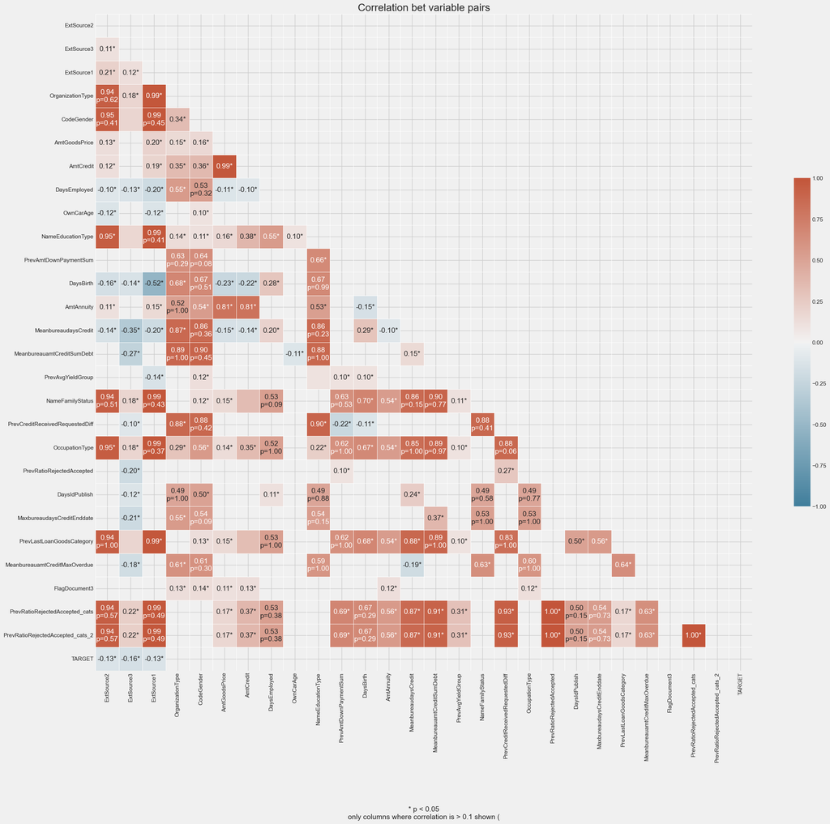

The `TARGET` variable (loans with payment difficulties) is most correlated with credit ratings obtained from external sources. The correlation is very weak but still significant.

| Column | Coefficient | P-Value |
| --- | --- | --- |
| ExtSource3 | -0.161 | 0.000 |
| ExtSource1 | -0.131 | 0.000 |
| ExtSource2 | -0.128 | 0.000 |
| MeanbureaudaysCredit | 0.093 | 0.000 |
| OccupationType | 0.075 | 0.000 |
| DaysEmployed | 0.074 | 0.000 |
| PrevRatioRejectedAccepted | 0.073 | 0.000 |
| PrevRatioRejectedAccepted_cats | 0.072 | 0.000 |
| PrevRatioRejectedAccepted_cats_2 | 0.072 | 0.000 |
| OrganizationType | 0.069 | 0.000 |
| NameEducationType | 0.067 | 0.000 |
| PrevAmtDownPaymentSum | -0.057 | 0.000 |
| PrevCreditReceivedRequestedDiff | 0.055 | 0.000 |
| DaysBirth | 0.053 | 0.000 |
| PrevLastLoanGoodsCategory | 0.051 | 0.000 |
| OwnCarAge | 0.050 | 0.000 |
| MeanbureauamtCreditSumDebt | 0.049 | 0.000 |
| MeanbureauamtCreditMaxOverdue | 0.044 | 0.000 |
| DaysIdPublish | 0.042 | 0.000 |
| CodeGender | 0.041 | 0.000 |
| PrevAvgYieldGroup | 0.040 | 0.000 |
| FlagDocument3 | 0.039 | 0.000 |
| AmtGoodsPrice | -0.034 | 0.000 |
| MaxbureaudaysCreditEnddate | 0.034 | 0.000 |
| NameFamilyStatus | 0.027 | 0.002 |
| AmtCredit | -0.023 | 0.001 |

`` Because the datatypes of features vary we had to use different methods to measure the strength and significance of each pair:

- Chi-Squared Test: Assesses independence between two categorical variables. For bool-bool pairs due to categorical nature.
- Point Biserial Correlation: Measures correlation between a binary and a continuous variable. For bool-numerical pairs to account for mixed data types.
- Spearman's Rank Correlation: Assesses monotonic relationship between two continuous variables. Used for numerical-numerical pairs (for non-normally distributed data).

Since the Chi-Squared test outputs an unbound statistic/value which can't be directly compared to pointbiserialr or Spearman Rank we have converted them to a `Cramér's V:` value which is normalized between 0 and 1. This was done to make the values in the matrix more uniform however we must note that Cramér's V and Spearman's correlation coefficients are fundamentally different statistics and generally can't be directly compared.

```
CategoricalDtype(categories=['< 25% Rejected', '> 25% Rejected', 'All Accepted', 'No Previous App.'], ordered=False, categories_dtype=object)
```

The chart below shows the relationship between selected categorical variables and loan status. E.g. a significantly higher proportion of loans taken out by males had issues.

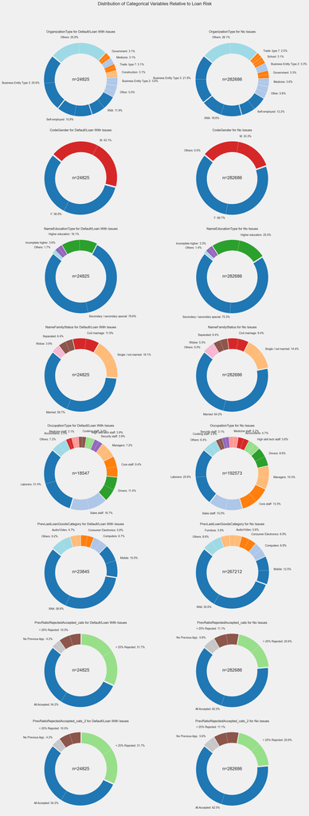

```
CategoricalDtype(categories=['< 25% Rejected', '> 25% Rejected', 'All Accepted', 'No Previous App.'], ordered=False, categories_dtype=object)
```

#### Relationships Between Numerical and Categorical Variables

The charts below show pairs of numerical and categorical features (including some binned numerical features) that have a signficant relationships and at least a small effect size (`eta_squared`>0.01) based on the non-parametric Kruskal-Wallis Test (one-way ANOVA on ranks) testing whether samples originate from the same distribution.

*`It's similar to the Mann–Whitney U test but allows comparing more than 2 groups`

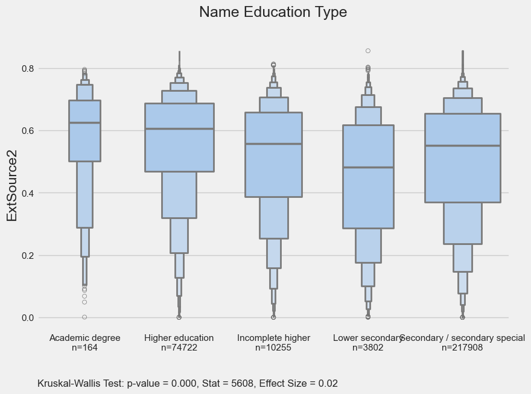

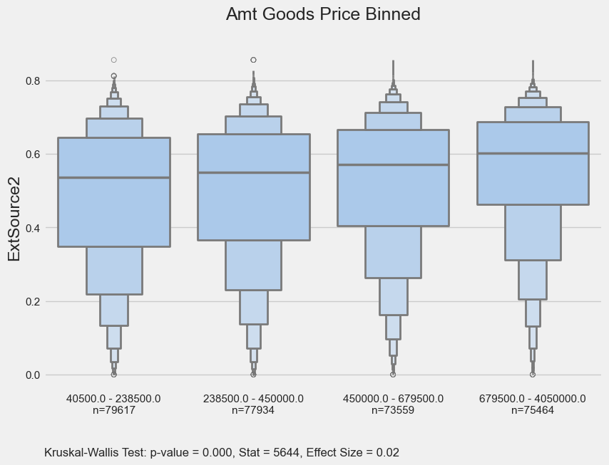

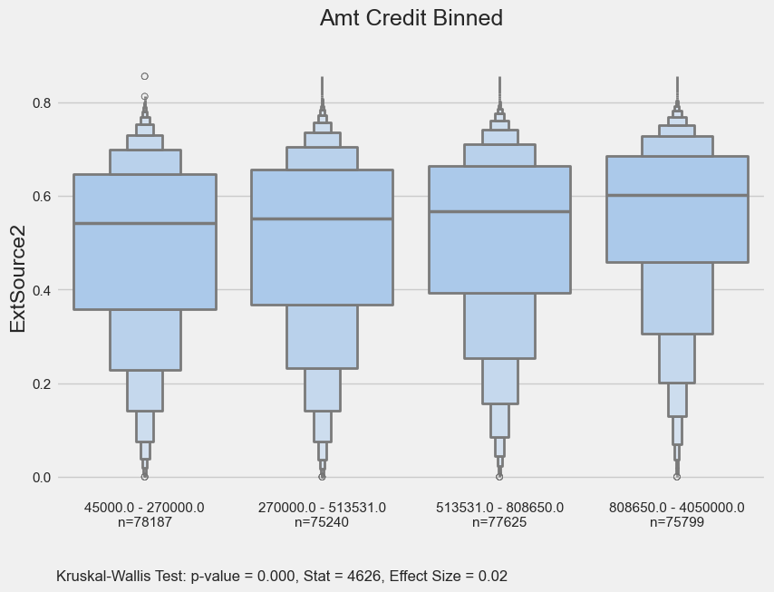

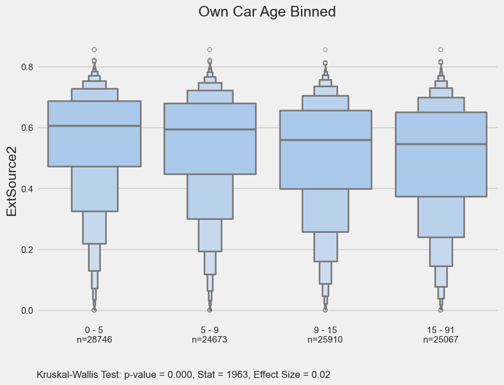

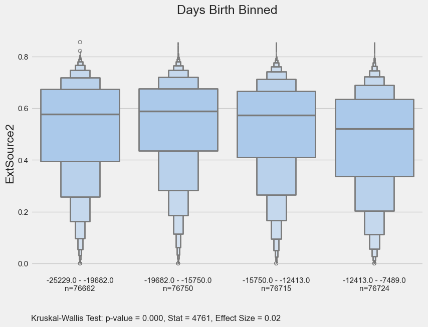

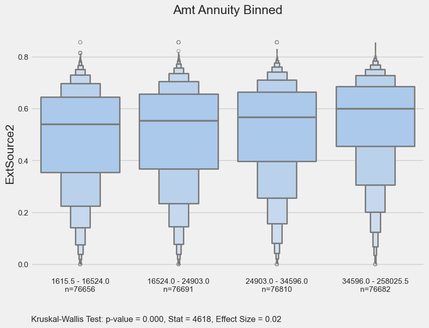

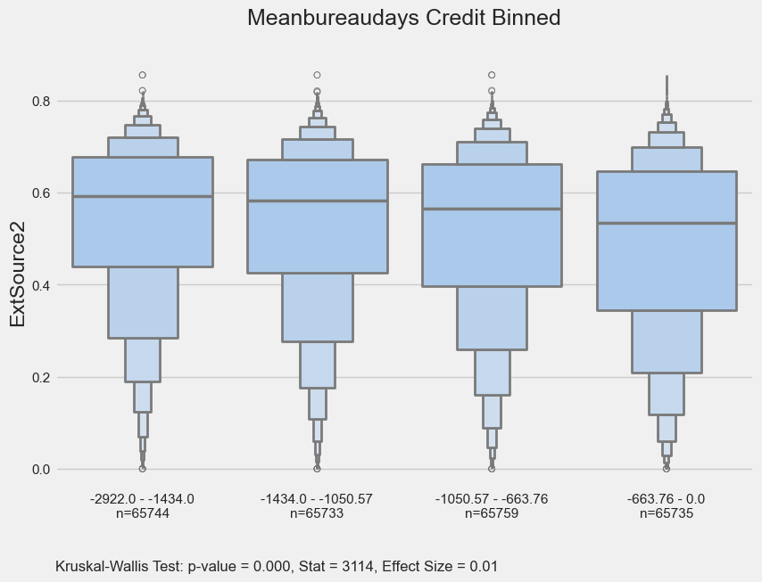

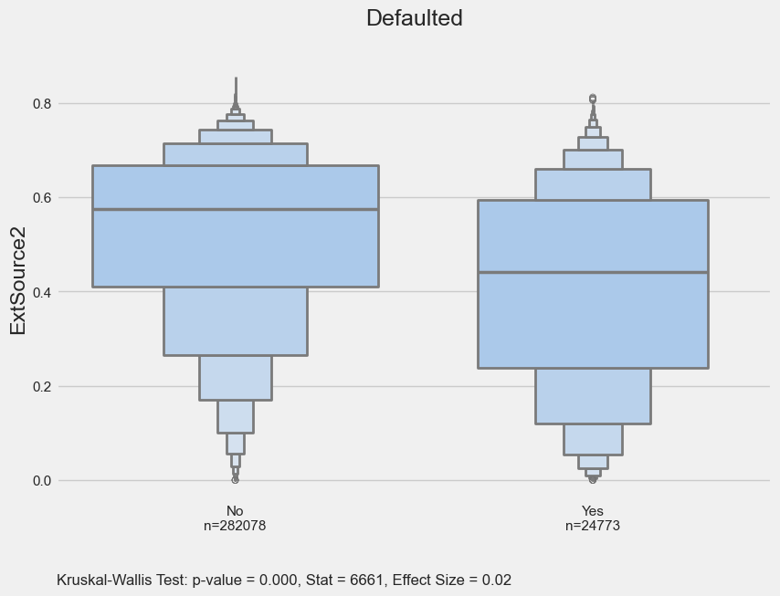

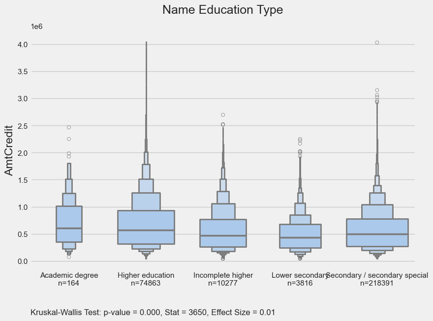

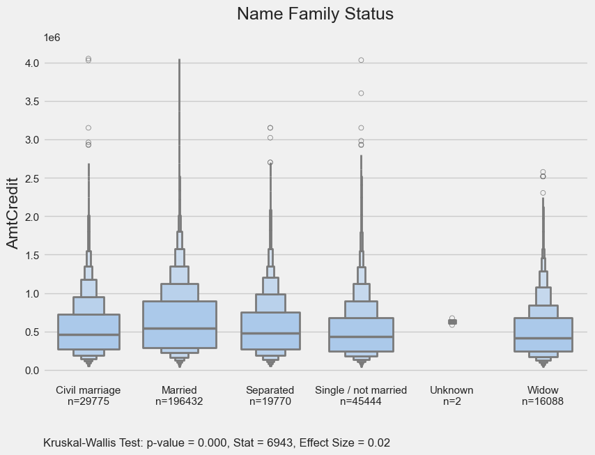

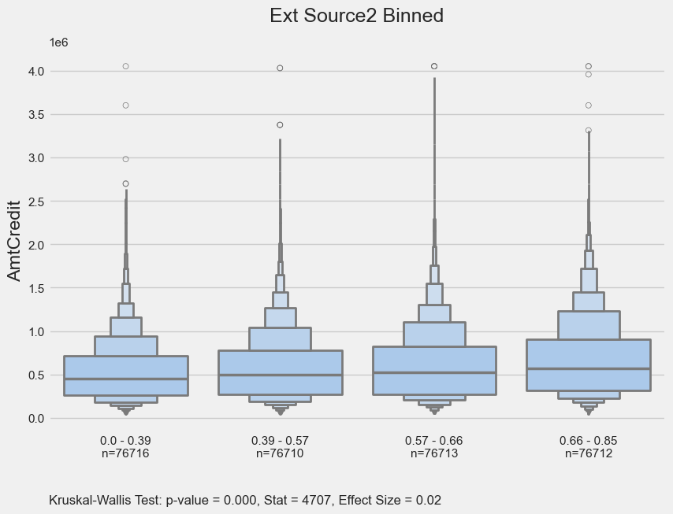

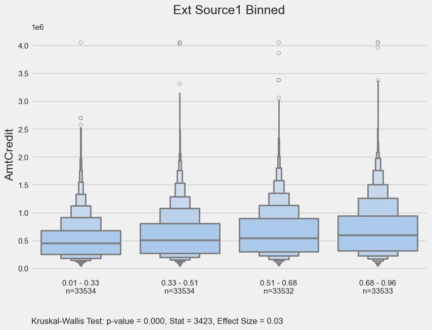

[14 more figures not shown]

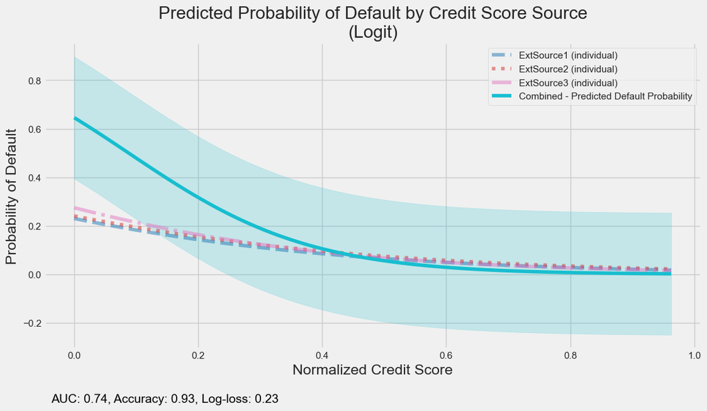

|  | Coefficient | Standard Error | P-Value | Conf. Interval Lower | Conf. Interval Upper |
| --- | --- | --- | --- | --- | --- |
| const | 0.600 | 0.040 | 0.0 | 0.521 | 0.680 |
| ExtSource1 | -2.099 | 0.061 | 0.0 | -2.219 | -1.979 |
| ExtSource2 | -1.964 | 0.060 | 0.0 | -2.082 | -1.846 |
| ExtSource3 | -2.779 | 0.062 | 0.0 | -2.902 | -2.657 |

Normalized credit ratings from three sources are inversely related to default risk, with `ExtSource3` having the strongest influence. We can see that a basic Logistic model can already provide a reasonably high result (AUC = 0.74). However, we have to note that the results are based on the full training set and are only provided for EDA/feature analysis purposes. Full statistical modelling will be done in further sections.

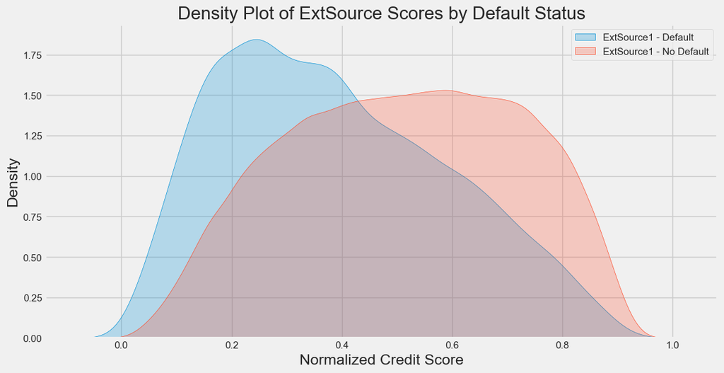

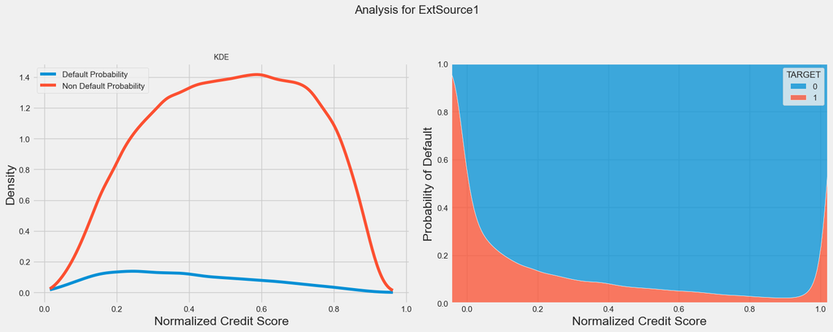

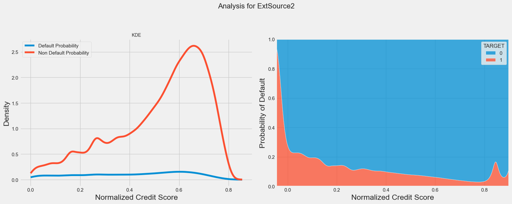

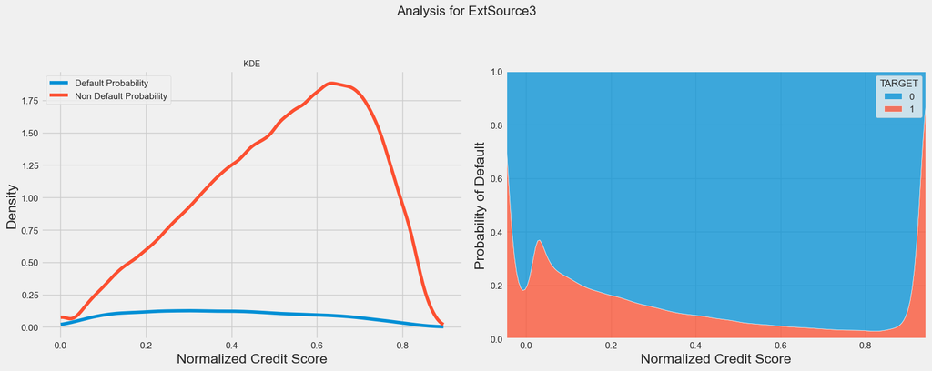

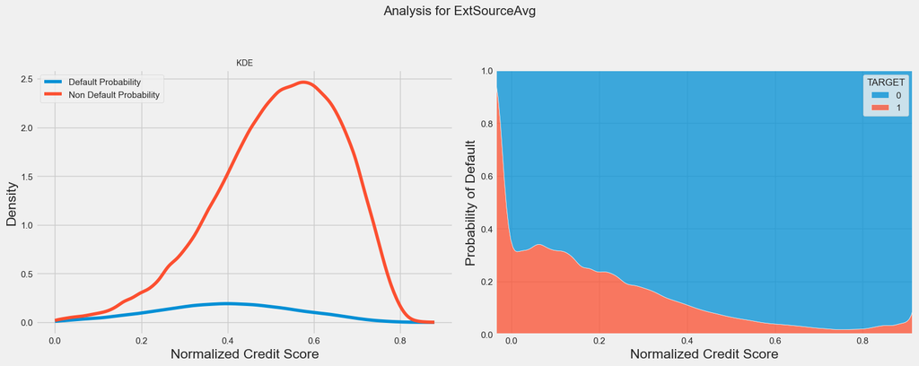

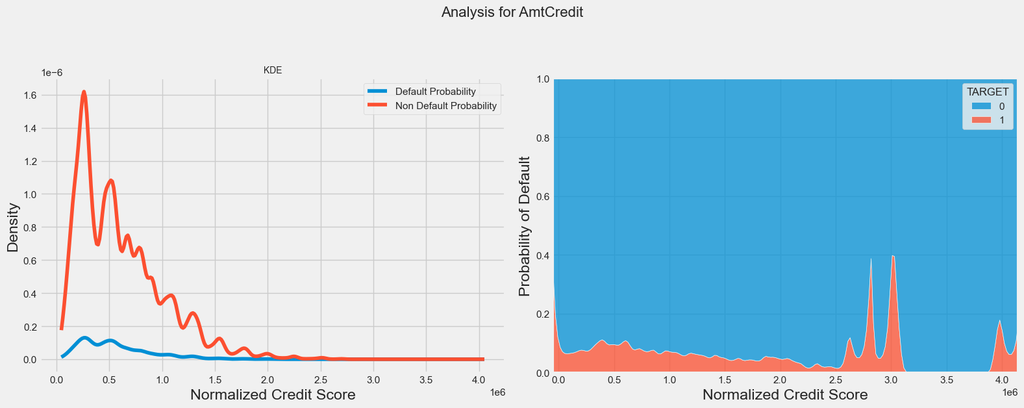

```
PrevRatioRejectedAccepted_cats
All Accepted        190370
> 25% Rejected       66215
< 25% Rejected       34079
No Previous App.     16847
Name: count, dtype: int64
```

```
TotalDefaults_cats
No Defaults          304114
1 Defaulted Loans      3397
Name: count, dtype: int64
```

[output not shown]